# Taxi and Limousine Comission (TLC) Green Cab Data

## Introduction

In this notebook, I provide analysis on taxi and limousine pickup/dropoff data provided to the Taxi and Limousine Corporation (TLC), and try to do the following:

- Report the number of rows and columns that loaded in the dataset
- Visualize trip distance by time of day and report any observations
- Identify the most popular pickup locations on weekends vs weekdays
- Build a model to forecast the number of trips by hour for the next 12 hours after Feb 12th 10:00 am, and evaluate the model's performance

## Data Source & Tooling

The data used was obtained from [NYC Taxi and Limousine Commission Website](https://www1.nyc.gov/site/tlc/about/tlc-trip-record-data.page), specifically, the Green Taxi trip records from February 2016.

I used the following python tools:

- Numpy
- Pandas
- Matplotlib's pyplot library
- Seaborn

For the final problem of creating a forecasting model, I used the `statsmodels` module, specifically, the ARIMA, ACF, PACF, and Augmented Dickey-Fuller (ADF) functions/classes. To evaluate the model, I used the R^2-score and mean squared error found in the `sklearn.metrics` module.

## Summary of Results

The exact details of how I obtained the following results can be found in the rest of the notebook. However, to answer the given questions:

#### Report the number of rows and columns that loaded in the dataset

There was 1,510,722 rows, and 21 columns loaded in the original dataset. I ended up dropping 2 rows that appeared to be erroneous, and 1 column that was entirely `NaN`.

#### Identify the most popular pickup locations on weekends vs weekdays

To identify the most popular pickup locations, I used `seaborn`'s `distplot` and `jointplot` functions to construct the distribution of the pickup latitude and longitude on weekends vs. weekdays. I read off the summary statistics to find the exact coordinate where the peak occurs.

On weekends, the most popular pickup locations appear to be centered around the coordinates `(40.680267,-73.834705)`- close to the corner of 107th Ave and 105th St. On weekdays, this center moves a few blocks down to the coordinates `(40.67670,-73.81199)` - the corner of 116th Ave and 126th St.

#### Build a model to forecast the number of trips by hour for the next 12 hours after Feb 12th 10:00 am, and evaluate the model's performance

I obtained the hourly pickup demand using pandas' `resample` function to obtain a count at each hour. One assumption for the ARIMA model is that data is [stationary](https://en.wikipedia.org/wiki/Stationary_process#Strict-sense_stationarity). I used the Augmented Dickey-Fuller test (`adfuller` in the `statsmodels.tsa.stattools` module) to test for stationarity. This test showed that while the raw count per hour data was unlikely to be sationary, it is safe at `95%` confidence to conclude that the first differenced and percentage change from previous were stationary.

In addition to observing trend and seasonality of a time series, the ACF and PACF plots provide a visual guide for what value of `p` in the `ARIMA(p,d,q)` model to use. In our case, `p=2` seemed to be a good choice. After fitting an `ARIMA(2,0,0)` model to the first differenced and percentage change data, their R^2 scores were compared. The first differenced data had a negative R^2 score which means that the `ARIMA(2,0,0)` model performs worse than just using the horizontal line, `y=mean`, to make predictions. The model performed much better on the percentage change data having an R^2 score of about `15%`.

```python
import numpy as np
import pandas as pd
import matplotlib.pyplot as plt
import seaborn as sns

%matplotlib inline

FIGSIZE = (15,11) # figure size for all my subplots
```

```python
df = pd.read_csv('green_tripdata_2016-02.csv')

df.head()
```

|  | VendorID | lpep_pickup_datetime | Lpep_dropoff_datetime | Store_and_fwd_flag | RateCodeID | Pickup_longitude | Pickup_latitude | Dropoff_longitude | Dropoff_latitude | Passenger_count | ... | Fare_amount | Extra | MTA_tax | Tip_amount | Tolls_amount | Ehail_fee | improvement_surcharge | Total_amount | Payment_type | Trip_type |
| --- | --- | --- | --- | --- | --- | --- | --- | --- | --- | --- | --- | --- | --- | --- | --- | --- | --- | --- | --- | --- | --- |
| 0 | 2 | 2016-02-01 00:00:01 | 2016-02-01 00:10:06 | N | 1 | -73.939018 | 40.805214 | -73.972534 | 40.785885 | 1 | ... | 10.5 | 0.5 | 0.5 | 0.00 | 0.0 | NaN | 0.3 | 11.80 | 2 | 1.0 |
| 1 | 2 | 2016-02-01 00:01:33 | 2016-02-01 00:20:13 | N | 1 | -73.891495 | 40.746651 | -73.890877 | 40.743896 | 1 | ... | 13.0 | 0.5 | 0.5 | 0.00 | 0.0 | NaN | 0.3 | 14.30 | 2 | 1.0 |
| 2 | 2 | 2016-02-01 00:03:46 | 2016-02-01 00:21:04 | N | 1 | -73.983780 | 40.676132 | -73.956978 | 40.718327 | 1 | ... | 17.5 | 0.5 | 0.5 | 3.76 | 0.0 | NaN | 0.3 | 22.56 | 1 | 1.0 |
| 3 | 2 | 2016-02-01 00:00:05 | 2016-02-01 00:06:48 | N | 1 | -73.807518 | 40.700375 | -73.831657 | 40.705978 | 1 | ... | 8.0 | 0.5 | 0.5 | 0.00 | 0.0 | NaN | 0.3 | 9.30 | 2 | 1.0 |
| 4 | 2 | 2016-02-01 00:06:20 | 2016-02-01 00:08:47 | N | 1 | -73.903961 | 40.744934 | -73.900009 | 40.733601 | 5 | ... | 5.0 | 0.5 | 0.5 | 0.00 | 0.0 | NaN | 0.3 | 6.30 | 2 | 1.0 |

5 rows × 21 columns

```python
df.shape
```

```
(1510722, 21)
```

There are $1510722$ rows and 21 columns in our dataset.

```python
df.info()
```

```
<class 'pandas.core.frame.DataFrame'>
RangeIndex: 1510722 entries, 0 to 1510721
Data columns (total 21 columns):
 #   Column                 Non-Null Count    Dtype
---  ------                 --------------    -----
 0   VendorID               1510722 non-null  int64
 1   lpep_pickup_datetime   1510722 non-null  object
 2   Lpep_dropoff_datetime  1510722 non-null  object
 3   Store_and_fwd_flag     1510722 non-null  object
 4   RateCodeID             1510722 non-null  int64
 5   Pickup_longitude       1510722 non-null  float64
 6   Pickup_latitude        1510722 non-null  float64
 7   Dropoff_longitude      1510722 non-null  float64
 8   Dropoff_latitude       1510722 non-null  float64
 9   Passenger_count        1510722 non-null  int64
 10  Trip_distance          1510722 non-null  float64
 11  Fare_amount            1510722 non-null  float64
 12  Extra                  1510722 non-null  float64
 13  MTA_tax                1510722 non-null  float64
 14  Tip_amount             1510722 non-null  float64
 15  Tolls_amount           1510722 non-null  float64
 16  Ehail_fee              0 non-null        float64
 17  improvement_surcharge  1510722 non-null  float64
 18  Total_amount           1510722 non-null  float64
 19  Payment_type           1510722 non-null  int64
 20  Trip_type              1510720 non-null  float64
dtypes: float64(14), int64(4), object(3)
memory usage: 242.0+ MB
```

Do the following to the columns names for ease of access:

- Make all the letters lower-case
- Cleanup unecessary white space in the column names

```python
df.columns
```

```
Index(['VendorID', 'lpep_pickup_datetime', 'Lpep_dropoff_datetime',
       'Store_and_fwd_flag', 'RateCodeID', 'Pickup_longitude',
       'Pickup_latitude', 'Dropoff_longitude', 'Dropoff_latitude',
       'Passenger_count', 'Trip_distance', 'Fare_amount', 'Extra', 'MTA_tax',
       'Tip_amount', 'Tolls_amount', 'Ehail_fee', 'improvement_surcharge',
       'Total_amount', 'Payment_type', 'Trip_type '],
      dtype='object')
```

```python
df.columns = [col.strip().lower() for col in df.columns]
df.columns
```

```
Index(['vendorid', 'lpep_pickup_datetime', 'lpep_dropoff_datetime',
       'store_and_fwd_flag', 'ratecodeid', 'pickup_longitude',
       'pickup_latitude', 'dropoff_longitude', 'dropoff_latitude',
       'passenger_count', 'trip_distance', 'fare_amount', 'extra', 'mta_tax',
       'tip_amount', 'tolls_amount', 'ehail_fee', 'improvement_surcharge',
       'total_amount', 'payment_type', 'trip_type'],
      dtype='object')
```

## Missing values

Our dataset is (broadly) free of missing values.

```python
df.isna().sum()
```

```
vendorid                       0
lpep_pickup_datetime           0
lpep_dropoff_datetime          0
store_and_fwd_flag             0
ratecodeid                     0
pickup_longitude               0
pickup_latitude                0
dropoff_longitude              0
dropoff_latitude               0
passenger_count                0
trip_distance                  0
fare_amount                    0
extra                          0
mta_tax                        0
tip_amount                     0
tolls_amount                   0
ehail_fee                1510722
improvement_surcharge          0
total_amount                   0
payment_type                   0
trip_type                      2
dtype: int64
```

Since the ehail_fee is empty in all rows, it can be dropped for this analysis.

```python
df = df.drop(['ehail_fee'], axis = 1)
df.info()
```

```
<class 'pandas.core.frame.DataFrame'>
RangeIndex: 1510722 entries, 0 to 1510721
Data columns (total 20 columns):
 #   Column                 Non-Null Count    Dtype
---  ------                 --------------    -----
 0   vendorid               1510722 non-null  int64
 1   lpep_pickup_datetime   1510722 non-null  object
 2   lpep_dropoff_datetime  1510722 non-null  object
 3   store_and_fwd_flag     1510722 non-null  object
 4   ratecodeid             1510722 non-null  int64
 5   pickup_longitude       1510722 non-null  float64
 6   pickup_latitude        1510722 non-null  float64
 7   dropoff_longitude      1510722 non-null  float64
 8   dropoff_latitude       1510722 non-null  float64
 9   passenger_count        1510722 non-null  int64
 10  trip_distance          1510722 non-null  float64
 11  fare_amount            1510722 non-null  float64
 12  extra                  1510722 non-null  float64
 13  mta_tax                1510722 non-null  float64
 14  tip_amount             1510722 non-null  float64
 15  tolls_amount           1510722 non-null  float64
 16  improvement_surcharge  1510722 non-null  float64
 17  total_amount           1510722 non-null  float64
 18  payment_type           1510722 non-null  int64
 19  trip_type              1510720 non-null  float64
dtypes: float64(13), int64(4), object(3)
memory usage: 230.5+ MB
```

```python
df.loc[df.isna().any(axis=1)]
```

|  | vendorid | lpep_pickup_datetime | lpep_dropoff_datetime | store_and_fwd_flag | ratecodeid | pickup_longitude | pickup_latitude | dropoff_longitude | dropoff_latitude | passenger_count | trip_distance | fare_amount | extra | mta_tax | tip_amount | tolls_amount | improvement_surcharge | total_amount | payment_type | trip_type |
| --- | --- | --- | --- | --- | --- | --- | --- | --- | --- | --- | --- | --- | --- | --- | --- | --- | --- | --- | --- | --- |
| 365145 | 1 | 2016-02-08 08:21:19 | 2016-02-08 12:21:19 | Y | 99 | -73.946999 | 40.831448 | 0.0 | 0.0 | 0 | 0.0 | 7.55 | 0.0 | 0.0 | 0.0 | 0.0 | 0.0 | 7.55 | 1 | NaN |
| 744932 | 1 | 2016-02-15 09:35:34 | 2016-02-15 13:35:34 | Y | 99 | -73.943428 | 40.825996 | 0.0 | 0.0 | 0 | 0.0 | 9.95 | 0.0 | 0.0 | 0.0 | 0.0 | 0.0 | 9.95 | 1 | NaN |

Let's drop these two rows since they appear to be eroneous and are unlikely to add any additional information to our analysis.

```python
df.dropna(axis=0, inplace = True)
df.info()
```

```
<class 'pandas.core.frame.DataFrame'>
Int64Index: 1510720 entries, 0 to 1510721
Data columns (total 20 columns):
 #   Column                 Non-Null Count    Dtype
---  ------                 --------------    -----
 0   vendorid               1510720 non-null  int64
 1   lpep_pickup_datetime   1510720 non-null  object
 2   lpep_dropoff_datetime  1510720 non-null  object
 3   store_and_fwd_flag     1510720 non-null  object
 4   ratecodeid             1510720 non-null  int64
 5   pickup_longitude       1510720 non-null  float64
 6   pickup_latitude        1510720 non-null  float64
 7   dropoff_longitude      1510720 non-null  float64
 8   dropoff_latitude       1510720 non-null  float64
 9   passenger_count        1510720 non-null  int64
 10  trip_distance          1510720 non-null  float64
 11  fare_amount            1510720 non-null  float64
 12  extra                  1510720 non-null  float64
 13  mta_tax                1510720 non-null  float64
 14  tip_amount             1510720 non-null  float64
 15  tolls_amount           1510720 non-null  float64
 16  improvement_surcharge  1510720 non-null  float64
 17  total_amount           1510720 non-null  float64
 18  payment_type           1510720 non-null  int64
 19  trip_type              1510720 non-null  float64
dtypes: float64(13), int64(4), object(3)
memory usage: 242.0+ MB
```

Next, let's convert `lpep_pickup_datetime` and `lpep_dropoff_datetime` into `datetime` format.

```python
df['lpep_pickup_datetime'] = pd.to_datetime(df['lpep_pickup_datetime'])
df['lpep_dropoff_datetime'] = pd.to_datetime(df['lpep_dropoff_datetime'])

df.info()
```

```
<class 'pandas.core.frame.DataFrame'>
Int64Index: 1510720 entries, 0 to 1510721
Data columns (total 20 columns):
 #   Column                 Non-Null Count    Dtype
---  ------                 --------------    -----
 0   vendorid               1510720 non-null  int64
 1   lpep_pickup_datetime   1510720 non-null  datetime64[ns]
 2   lpep_dropoff_datetime  1510720 non-null  datetime64[ns]
 3   store_and_fwd_flag     1510720 non-null  object
 4   ratecodeid             1510720 non-null  int64
 5   pickup_longitude       1510720 non-null  float64
 6   pickup_latitude        1510720 non-null  float64
 7   dropoff_longitude      1510720 non-null  float64
 8   dropoff_latitude       1510720 non-null  float64
 9   passenger_count        1510720 non-null  int64
 10  trip_distance          1510720 non-null  float64
 11  fare_amount            1510720 non-null  float64
 12  extra                  1510720 non-null  float64
 13  mta_tax                1510720 non-null  float64
 14  tip_amount             1510720 non-null  float64
 15  tolls_amount           1510720 non-null  float64
 16  improvement_surcharge  1510720 non-null  float64
 17  total_amount           1510720 non-null  float64
 18  payment_type           1510720 non-null  int64
 19  trip_type              1510720 non-null  float64
dtypes: datetime64[ns](2), float64(13), int64(4), object(1)
memory usage: 242.0+ MB
```

## Visualize trip distance by time of day

- Create new features `pickup_hour` and `dropoff_hour` which describe the hour of pickup/dropoff
- Visualize the pickup

```python
df['pickup_hour'] = df['lpep_pickup_datetime'].dt.hour
df['dropoff_hour'] = df['lpep_dropoff_datetime'].dt.hour
```

```python
df['pickup_hour']
```

```
0           0
1           0
2           0
3           0
4           0
           ..
1510717    23
1510718    23
1510719    23
1510720    23
1510721    23
Name: pickup_hour, Length: 1510720, dtype: int64
```

```python
df['dropoff_hour']
```

```
0           0
1           0
2           0
3           0
4           0
           ..
1510717    23
1510718    23
1510719    23
1510720    23
1510721    23
Name: dropoff_hour, Length: 1510720, dtype: int64
```

```python
df['pickup_hour'].value_counts(normalize=True)
```

```
18    0.069730
19    0.068440
20    0.062123
17    0.062122
21    0.057410
16    0.055980
22    0.053608
15    0.049894
23    0.049739
14    0.046584
9     0.043076
13    0.041769
8     0.041760
0     0.040934
10    0.039134
12    0.038962
11    0.038892
1     0.030935
7     0.028563
2     0.023616
3     0.018112
4     0.014844
6     0.014050
5     0.009723
Name: pickup_hour, dtype: float64
```

```python
df['dropoff_hour'].value_counts(normalize=True)
```

```
19    0.070135
18    0.069367
20    0.063890
17    0.060684
21    0.057925
16    0.054459
22    0.053946
23    0.050712
15    0.048714
0     0.045272
14    0.045025
9     0.044017
13    0.040718
10    0.040415
8     0.039273
12    0.039232
11    0.038519
1     0.032410
2     0.024717
7     0.024053
3     0.018527
4     0.015996
6     0.012163
5     0.009831
Name: dropoff_hour, dtype: float64
```

It looks like pickups and dropoffs are most frequent during the evenings (1800-2100)

```
<BarContainer object of 24 artists>
```

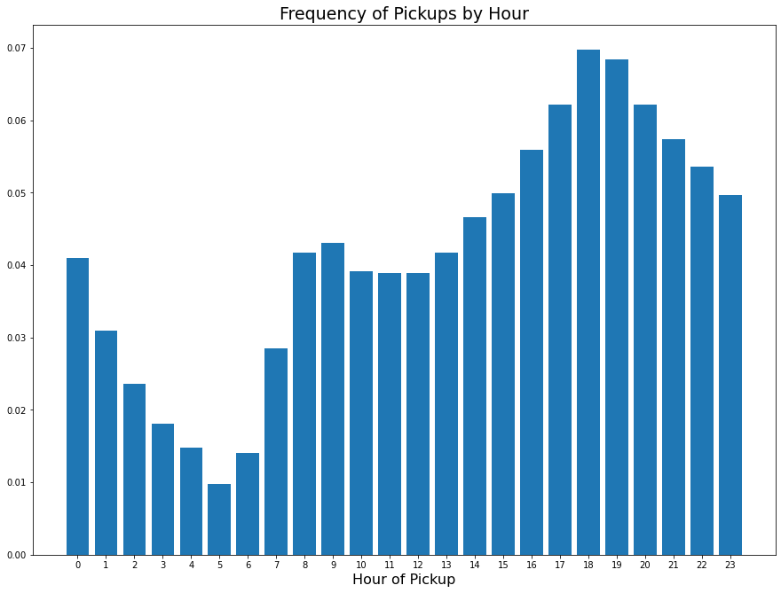

```python
fig, ax = plt.subplots(figsize=FIGSIZE)

xs = df['pickup_hour'].value_counts(normalize=True).index
heights = df['pickup_hour'].value_counts(normalize=True)

ax.set_title('Frequency of Pickups by Hour',fontsize=19)
ax.set_xticks(xs)
ax.set_xlabel('Hour of Pickup',fontsize=16)

plt.bar(xs, heights)
```

```
<BarContainer object of 24 artists>
```

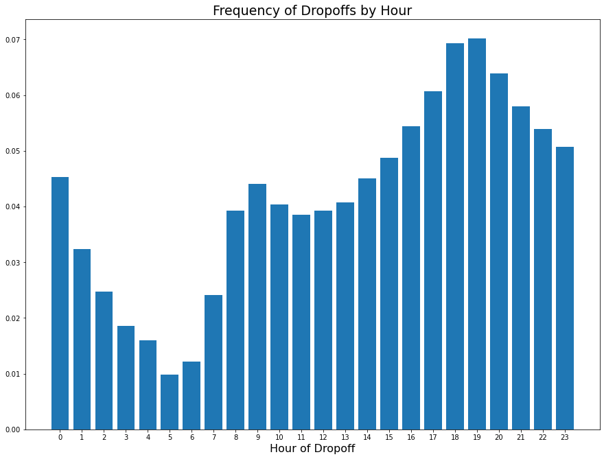

```python
fig, ax = plt.subplots(figsize=FIGSIZE)

xs = df['dropoff_hour'].value_counts(normalize=True).index
heights = df['dropoff_hour'].value_counts(normalize=True)

ax.set_title('Frequency of Dropoffs by Hour',fontsize=19)
ax.set_xticks(xs)
ax.set_xlabel('Hour of Dropoff',fontsize=16)

plt.bar(xs, heights)
```

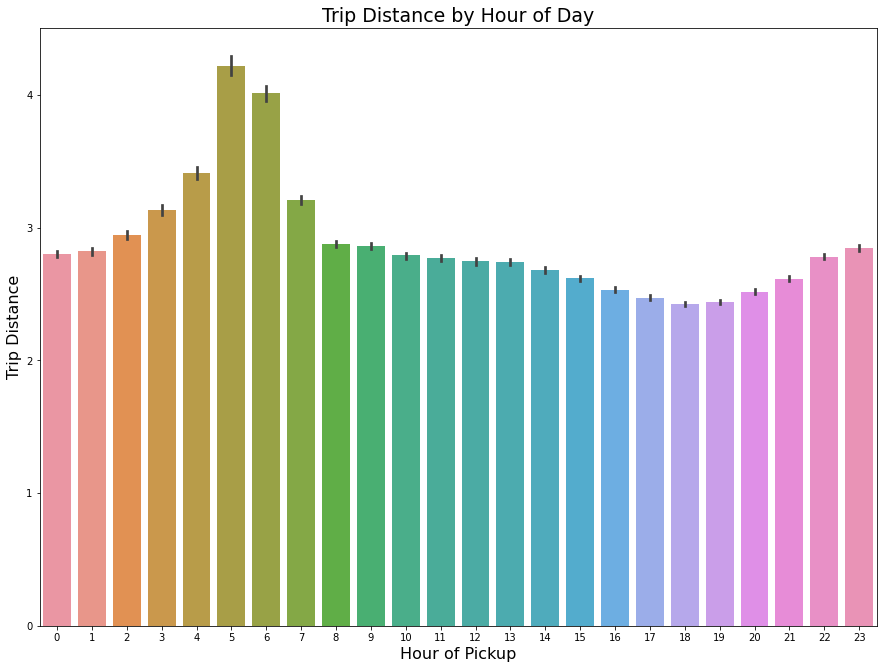

```python
fig, ax = plt.subplots(figsize=FIGSIZE)

ax.set_title('Trip Distance by Hour of Day',fontsize=19)

sns.barplot(x='pickup_hour', y='trip_distance',
            data = df,
            ax=ax)

ax.set_xlabel('Hour of Pickup', fontsize=16)
ax.set_ylabel('Trip Distance', fontsize=16)
```

Trip distance appears to be the highest between 4am and 7am, with the peak occuring at 5am.

## Pickup locations.

### Weekends vs. Weekdays

- Extract the day of the week from `lpep_pickup_datetime`
  - Monday - 0, ..., Sunday - 6
- Use day of week to create a new feature called `is_weekend`

```
<BarContainer object of 7 artists>
```

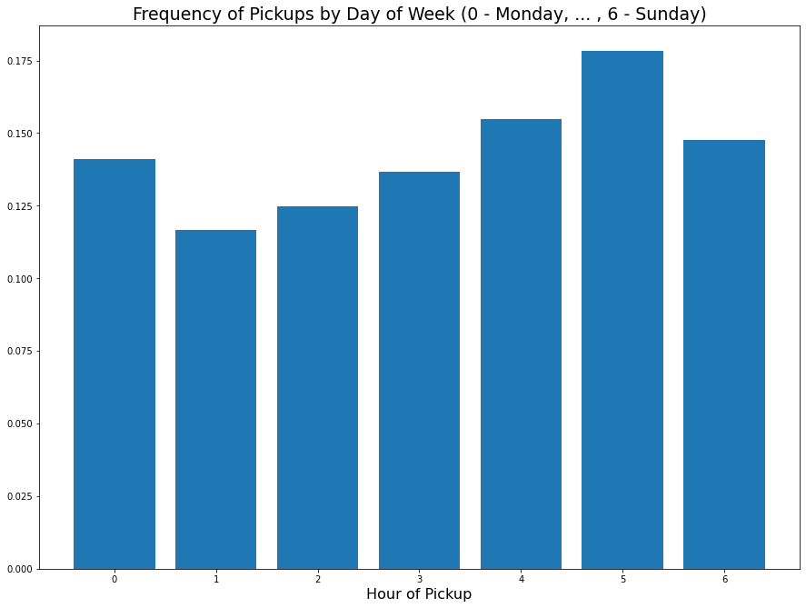

```python
fig, ax = plt.subplots(figsize=FIGSIZE)

heights = df['lpep_pickup_datetime'].dt.dayofweek.value_counts(normalize=True)
xs = heights.index

ax.set_title('Frequency of Pickups by Day of Week (0 - Monday, ... , 6 - Sunday)',fontsize=19)
ax.set_xticks(xs)
ax.set_xlabel('Hour of Pickup',fontsize=16)

plt.bar(xs, heights)
```

```python
df['pickup_day_of_week'] = df['lpep_pickup_datetime'].dt.dayofweek
```

```python
def is_weekend(day_of_week):
    return 1 if day_of_week in [5,6] else 0

df['is_weekend'] = df['pickup_day_of_week'].apply(is_weekend)
df['is_weekend'].value_counts(normalize=True)
```

```
0    0.67415
1    0.32585
Name: is_weekend, dtype: float64
```

```python
is_weekend_rows = df['is_weekend'] == 1
not_weekend_rows = (1 - is_weekend_rows).astype(bool)

weekend_pickup_loc_df = df.loc[is_weekend_rows,['pickup_longitude','pickup_latitude']]
weekday_pickup_loc_df = df.loc[not_weekend_rows,['pickup_longitude','pickup_latitude']]
```

```python
weekend_pickup_loc_df.describe()
```

|  | pickup_longitude | pickup_latitude |
| --- | --- | --- |
| count | 492268.000000 | 492268.000000 |
| mean | -73.834705 | 40.680267 |
| std | 2.953090 | 1.590570 |
| min | -115.222740 | 0.000000 |
| 25% | -73.960587 | 40.693531 |
| 50% | -73.947304 | 40.741508 |
| 75% | -73.919205 | 40.796745 |
| max | 0.000000 | 41.507202 |

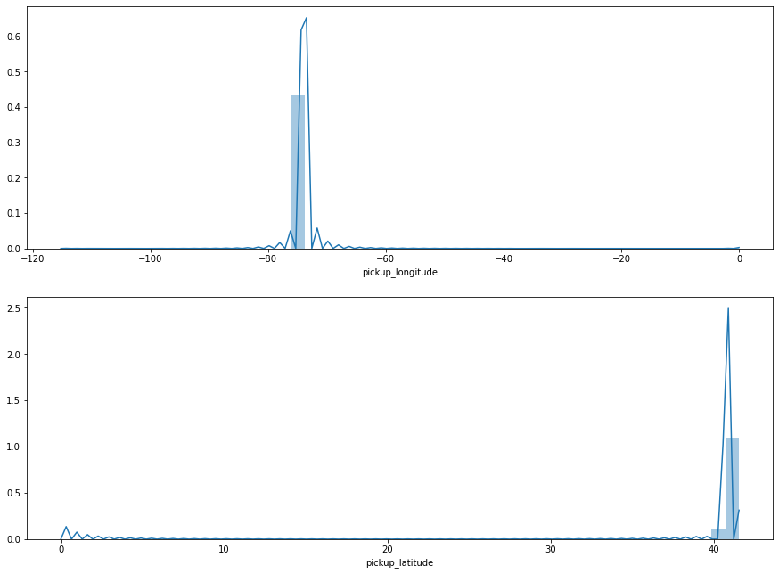

```python
fig, (ax1, ax2) = plt.subplots(nrows=2, figsize=FIGSIZE)

sns.distplot(weekend_pickup_loc_df['pickup_longitude'],
             ax=ax1)

sns.distplot(weekend_pickup_loc_df['pickup_latitude'],
             ax=ax2)
```

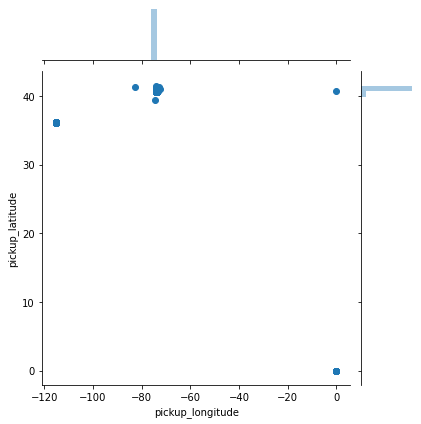

```python
sns.jointplot(data=weekend_pickup_loc_df, x='pickup_longitude', y='pickup_latitude')
```

```python
weekday_pickup_loc_df.describe()
```

|  | pickup_longitude | pickup_latitude |
| --- | --- | --- |
| count | 1.018452e+06 | 1.018452e+06 |
| mean | -7.381199e+01 | 4.067670e+01 |
| std | 3.168343e+00 | 1.722193e+00 |
| min | -1.152825e+02 | 0.000000e+00 |
| 25% | -7.396102e+01 | 4.069512e+01 |
| 50% | -7.394650e+01 | 4.074726e+01 |
| 75% | -7.391892e+01 | 4.080416e+01 |
| max | 0.000000e+00 | 4.232435e+01 |

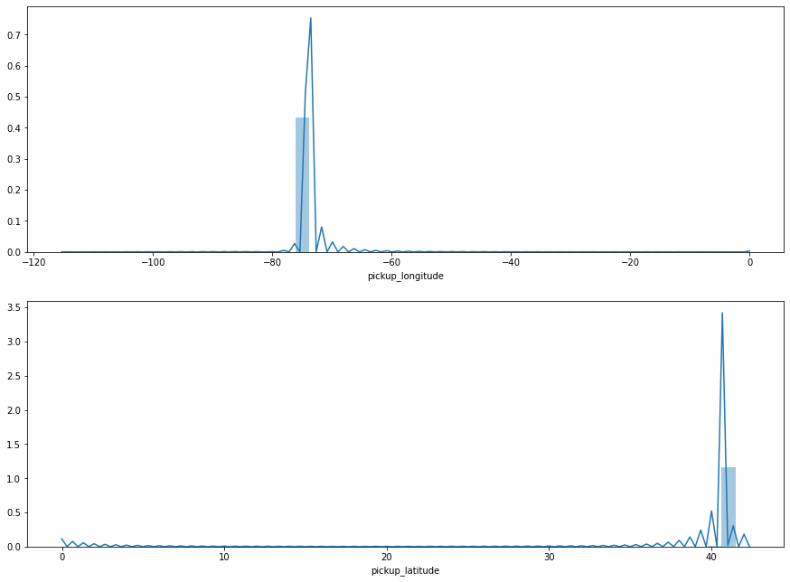

```python
fig, (ax1, ax2) = plt.subplots(nrows=2, figsize=FIGSIZE)

sns.distplot(weekday_pickup_loc_df['pickup_longitude'],
             ax=ax1)

sns.distplot(weekday_pickup_loc_df['pickup_latitude'],
             ax=ax2)
```

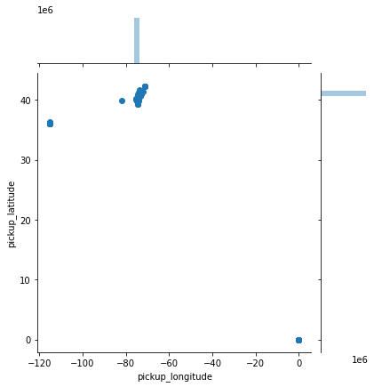

```python
sns.jointplot(data=weekday_pickup_loc_df, x='pickup_longitude', y='pickup_latitude')
```

On weekends, the most popular pickup locations appear to be centered around the coordinates `(40.680267,-73.834705)`, whereas on weekdays, this center moves to the coordinates `(40.67670,-73.81199)`

## Forecast Trip demand by Hour

```python
pickups_per_hour = df.loc[:,['lpep_pickup_datetime']].resample('H',on='lpep_pickup_datetime').count()

pickups_per_hour.head()
```

| lpep_pickup_datetime | lpep_pickup_datetime |
| --- | --- |
| 2016-02-01 00:00:00 | 1290 |
| 2016-02-01 01:00:00 | 819 |
| 2016-02-01 02:00:00 | 583 |
| 2016-02-01 03:00:00 | 431 |
| 2016-02-01 04:00:00 | 463 |

```python
pickups_per_hour.columns = ['number_of_pickups']
pickups_per_hour.head()
```

| lpep_pickup_datetime | number_of_pickups |
| --- | --- |
| 2016-02-01 00:00:00 | 1290 |
| 2016-02-01 01:00:00 | 819 |
| 2016-02-01 02:00:00 | 583 |
| 2016-02-01 03:00:00 | 431 |
| 2016-02-01 04:00:00 | 463 |

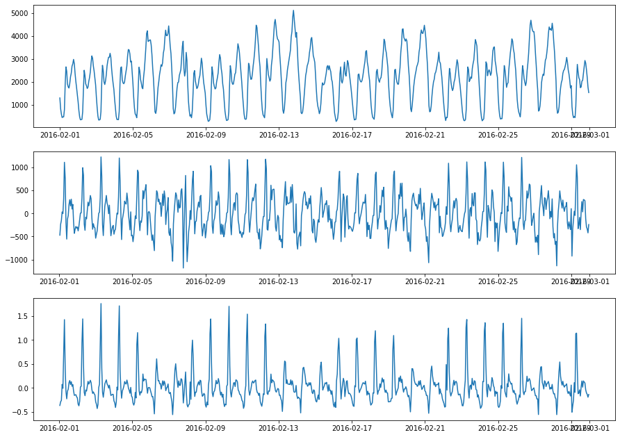

```python
fig, ax = plt.subplots(nrows = 3, figsize=FIGSIZE)

ax[0].plot(pickups_per_hour) # Plain Number of Pickups per Hour

ax[1].plot(pickups_per_hour.diff(1)) # Change in Number of Pickups from Previous Hour (First-Differenced)

ax[2].plot(pickups_per_hour.pct_change(1)) # Percentage Change in Number of Pickups from Previous Hour (Pct_change)
```

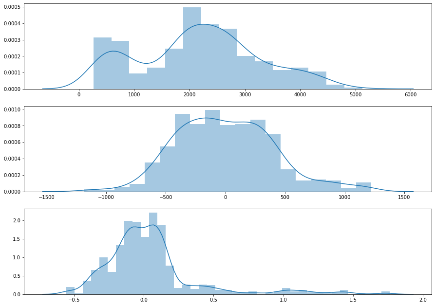

```python
fig, ax = plt.subplots(nrows = 3,
                   figsize=FIGSIZE)

sns.distplot(pickups_per_hour,
             ax=ax[0])

sns.distplot(pickups_per_hour.diff(1),
             ax=ax[1])

sns.distplot(pickups_per_hour.pct_change(1),
             ax=ax[2])
```

```python
# Import Augmented Dickey-Fuller test.
# This is a statistical test to determine whether a time-series is stationary or not
from statsmodels.tsa.stattools import adfuller
```

```python
adftest = adfuller(pickups_per_hour)
adftest_diff = adfuller(pickups_per_hour.diff().dropna())
adftest_pct_change = adfuller(pickups_per_hour.pct_change().dropna())
```

```python
def interpret_dftest(dftest):
    dfoutput = pd.Series(dftest[0:2], index=['Test Statistic','p-value'])
    return dfoutput

print(f'Raw Data:\n{interpret_dftest(adftest)}\n')
print(f'First-differenced Data:\n{interpret_dftest(adftest_diff)}\n')
print(f'Percent Change from Previous:\n{interpret_dftest(adftest_pct_change)}\n')
```

```
Raw Data:
Test Statistic   -2.511145
p-value           0.112786
dtype: float64

First-differenced Data:
Test Statistic   -1.854940e+01
p-value           2.093273e-30
dtype: float64

Percent Change from Previous:
Test Statistic   -1.805292e+01
p-value           2.636088e-30
dtype: float64
```

Using the Augmented Dickey-Fuller test, we get the following results:

- Fail to reject the hypothesis that the undifferenced series is not stationary (at 95% confidence)
- Reject the hypothesis that the percentage change and first difference in taxi pickup demand from the previous hour is not stationary
  - It is safe (at 95% confidence) to accept the claim that the dataset obtained by finding the percent change in demand from the previous hour is a stationary time series

```python
# Import the autocorrelation function (ACF) plot and partial autocorrelation function (PACF) plot tools.
# These can be used to determine which value of p in ARIMA(p,d,q),
## as well as to observe trend and seasonality of the time series

from statsmodels.graphics.tsaplots import plot_acf, plot_pacf
```

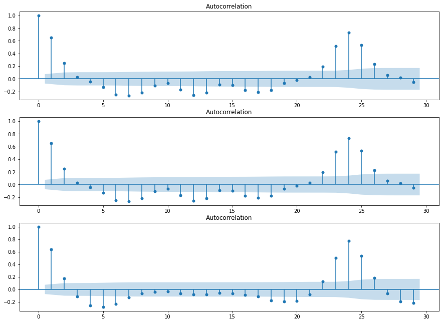

[figure not shown]

```python
fig, ax = plt.subplots(nrows=3, figsize=FIGSIZE)

plot_acf(pickups_per_hour.diff(1).dropna(), ax = ax[0])
plot_acf(pickups_per_hour.diff(1).dropna(), ax = ax[1])
plot_acf(pickups_per_hour.pct_change(1).dropna(), ax = ax[2])
```

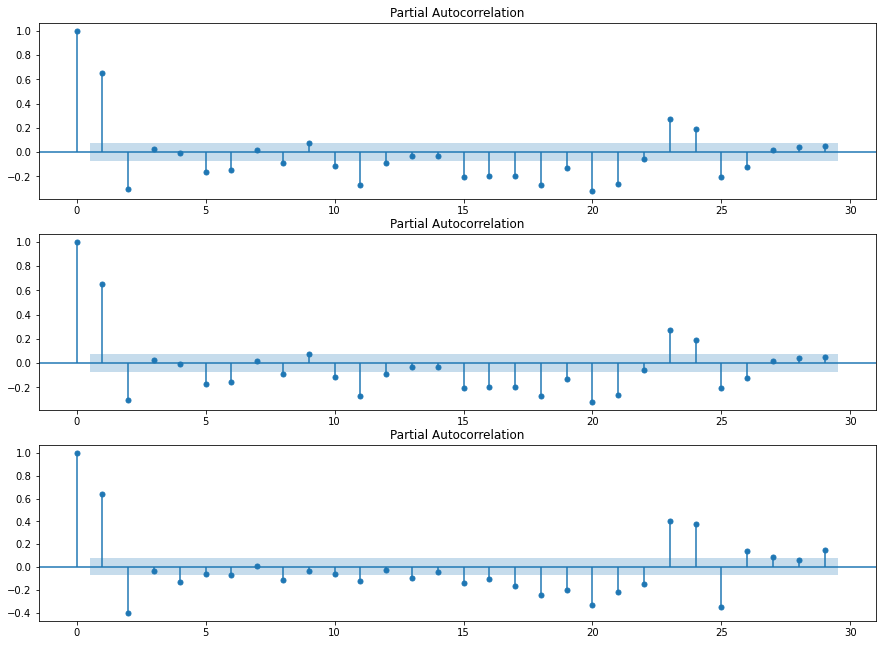

[figure not shown]

```python
fig, ax = plt.subplots(nrows=3, figsize=FIGSIZE)

plot_pacf(pickups_per_hour.diff(1).dropna(), ax = ax[0])
plot_pacf(pickups_per_hour.diff(1).dropna(), ax = ax[1])
plot_pacf(pickups_per_hour.pct_change(1).dropna(), ax = ax[2])
```

The ACF and PACF plots give an idea for what value of `p` to use in the `ARIMA(p,d,q)` model. In this case, `p=2` seems to be a good choice.

```python
y_train_first_diff = pickups_per_hour[:'2016-02-12 10:00:00'].diff(1).dropna()
y_train_first_diff
```

| lpep_pickup_datetime | number_of_pickups |
| --- | --- |
| 2016-02-01 01:00:00 | -471.0 |
| 2016-02-01 02:00:00 | -236.0 |
| 2016-02-01 03:00:00 | -152.0 |
| 2016-02-01 04:00:00 | 32.0 |
| 2016-02-01 05:00:00 | -3.0 |
| ... | ... |
| 2016-02-12 06:00:00 | 457.0 |
| 2016-02-12 07:00:00 | 1174.0 |
| 2016-02-12 08:00:00 | 963.0 |
| 2016-02-12 09:00:00 | -343.0 |
| 2016-02-12 10:00:00 | -362.0 |

274 rows × 1 columns

```python
y_train_pct_change = pickups_per_hour[:'2016-02-12 10:00:00'].pct_change(1).dropna()
y_train_pct_change
```

| lpep_pickup_datetime | number_of_pickups |
| --- | --- |
| 2016-02-01 01:00:00 | -0.365116 |
| 2016-02-01 02:00:00 | -0.288156 |
| 2016-02-01 03:00:00 | -0.260720 |
| 2016-02-01 04:00:00 | 0.074246 |
| 2016-02-01 05:00:00 | -0.006479 |
| ... | ... |
| 2016-02-12 06:00:00 | 1.082938 |
| 2016-02-12 07:00:00 | 1.335609 |
| 2016-02-12 08:00:00 | 0.469070 |
| 2016-02-12 09:00:00 | -0.113727 |
| 2016-02-12 10:00:00 | -0.135428 |

274 rows × 1 columns

```python
y_test_first_diff = pickups_per_hour['2016-02-12 10:00:00':'2016-02-12 23:00:00'].diff(1).dropna()
y_test_first_diff
```

| lpep_pickup_datetime | number_of_pickups |
| --- | --- |
| 2016-02-12 11:00:00 | -136.0 |
| 2016-02-12 12:00:00 | -151.0 |
| 2016-02-12 13:00:00 | 82.0 |
| 2016-02-12 14:00:00 | 610.0 |
| 2016-02-12 15:00:00 | 293.0 |
| 2016-02-12 16:00:00 | 508.0 |
| 2016-02-12 17:00:00 | 523.0 |
| 2016-02-12 18:00:00 | 524.0 |
| 2016-02-12 19:00:00 | 161.0 |
| 2016-02-12 20:00:00 | -293.0 |
| 2016-02-12 21:00:00 | -384.0 |
| 2016-02-12 22:00:00 | -178.0 |
| 2016-02-12 23:00:00 | -42.0 |

```python
y_test_pct_change = pickups_per_hour['2016-02-12 10:00:00':'2016-02-12 23:00:00'].pct_change(1).dropna()
y_test_pct_change
```

| lpep_pickup_datetime | number_of_pickups |
| --- | --- |
| 2016-02-12 11:00:00 | -0.058849 |
| 2016-02-12 12:00:00 | -0.069425 |
| 2016-02-12 13:00:00 | 0.040514 |
| 2016-02-12 14:00:00 | 0.289649 |
| 2016-02-12 15:00:00 | 0.107879 |
| 2016-02-12 16:00:00 | 0.168827 |
| 2016-02-12 17:00:00 | 0.148706 |
| 2016-02-12 18:00:00 | 0.129703 |
| 2016-02-12 19:00:00 | 0.035276 |
| 2016-02-12 20:00:00 | -0.062011 |
| 2016-02-12 21:00:00 | -0.086643 |
| 2016-02-12 22:00:00 | -0.043972 |
| 2016-02-12 23:00:00 | -0.010853 |

```python
# Import models
from statsmodels.tsa.arima_model import ARIMA # Arima Model
```

```python
# Model Trained on First Differenced Data
model_first_diff = ARIMA(endog=y_train_first_diff.astype(float),
              order=(2,0,0))

arima_model_first_diff = model_first_diff.fit()
```

```python
# Model Trained on First Percentage Change
model_pct_change = ARIMA(endog=y_train_pct_change.astype(float),
              order=(2,0,0))

arima_model_pct_change = model_pct_change.fit()
```

```python
# Prediction on First Difference Data (12 hours after 10:00am)
y_pred_first_diff = model_first_diff.predict(params=arima_model_first_diff.params,
                            start=y_test_first_diff.index[0],
                            end=y_test_first_diff.index[-1])

# Prediction on First Percentage Change Data (12 hours after 10:00am
y_pred_pct_change = model_pct_change.predict(params=arima_model_pct_change.params,
                            start=y_test_pct_change.index[0],
                            end=y_test_pct_change.index[-1])
```

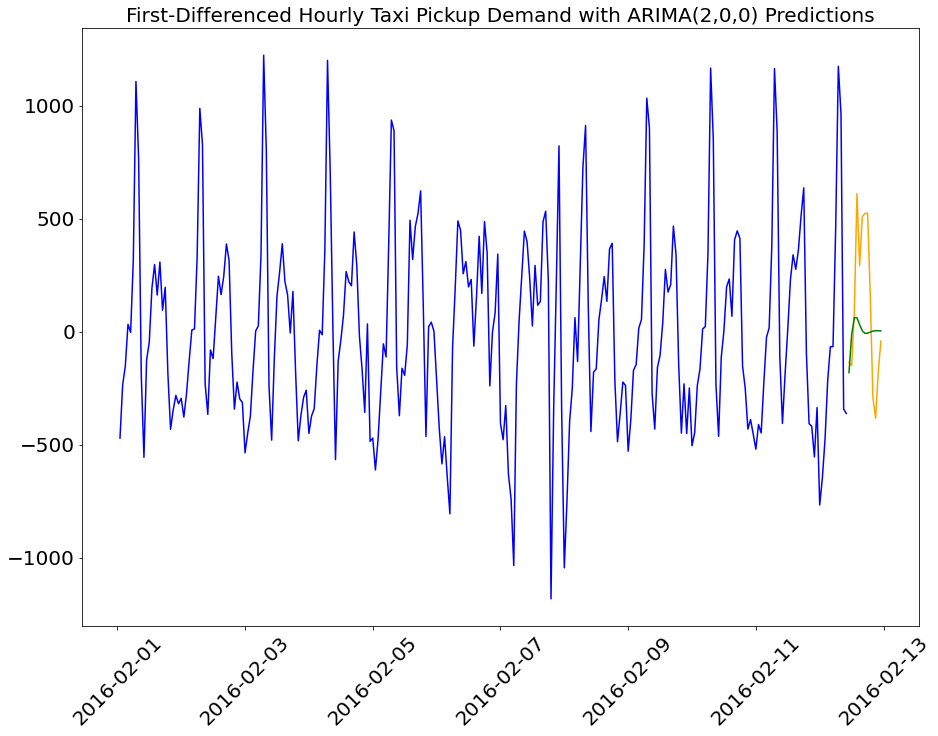

```python
# Plot data.
# Prediction is Green
# Actual data is orange

# Set figure size.
plt.figure(figsize=FIGSIZE)

# Plot training data.
plt.plot(y_train_first_diff.index, y_train_first_diff, color = 'blue')

# Plot testing data.
plt.plot(y_test_first_diff.index, y_test_first_diff, color = 'orange')

# Plot predicted test values.
plt.plot(y_test_first_diff.index, y_pred_first_diff, color = 'green')

# Set label.
plt.title(label = 'First-Differenced Hourly Taxi Pickup Demand with ARIMA(2,0,0) Predictions', fontsize=20)

# Resize tick marks.
plt.xticks(fontsize=20,rotation=45)
plt.yticks(fontsize=20);
```

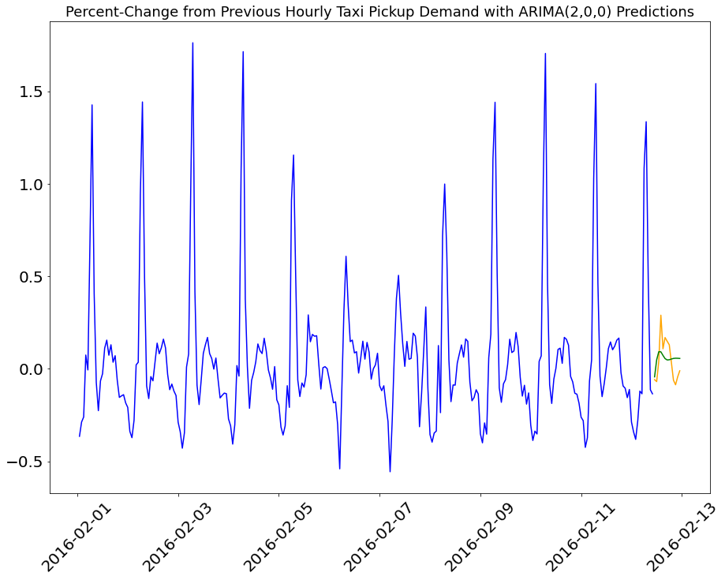

```python
# Plot data.

# Set figure size.
plt.figure(figsize=FIGSIZE)

# Plot training data.
plt.plot(y_train_pct_change.index, y_train_pct_change, color = 'blue')

# Plot testing data.
plt.plot(y_test_pct_change.index, y_test_pct_change, color = 'orange')

# Plot predicted test values.
plt.plot(y_test_pct_change.index, y_pred_pct_change, color = 'green')

# Set label.
plt.title(label = 'Percent-Change from Previous Hourly Taxi Pickup Demand with ARIMA(2,0,0) Predictions', fontsize=18)

# Resize tick marks.
plt.xticks(fontsize=20,rotation=45)
plt.yticks(fontsize=20);
```

```python
# Metrics

from sklearn.metrics import r2_score, mean_squared_error
```

```python
r2_score(y_test_first_diff,y_pred_first_diff)
```

```
-0.056096316422718395
```

A negative $R^2$ score means that the model performs worse than using a horizontal line to make predictions.

```python
mean_squared_error(y_test_first_diff,y_pred_first_diff)
```

```
115991.12092361346
```

```python
r2_score(y_test_pct_change,y_pred_pct_change)
```

```
0.1520311205470778
```

```python
mean_squared_error(y_test_pct_change,y_pred_pct_change)
```

```
0.010493770735597109
```